# Emulating nonstationary metric (response) produced by LMDZ

In this example we use primarily R and Stan files from **BuildEmulator** directory to construct and validate a nonstationary GP emulator [@volodina2018diagnostic]. In this example we encountered a nonstationary response, *qv500*, water vapour at 500 metres, against five input parameters.

First we start with loading the necessary packages, functions and compilation of Stan files that are necessary to construct a stationary and nonstationary GP emulators.

```r
setwd('..')
source('BuildEmulator/BuildEmulator.R')
source('BuildEmulator/BuildEmulatorNSt.R')
```

We proceed to loading the data file `qv500Wave1SCM.RData`. The model inputs (variables) are saved in columns 1 to 5 (on $[-1, 1]$ scale) of the object `tData` together with the `Noise` and the simulator response `qv500` saved as the last two columns of a data frame.

```r
load('../Demonstrations/qv500Wave1SCM.RData')
head(tData)
```

```
##   thermals_fact_epsilon thermals_ed_dz  cld_lc_lsc  rad_chaud1      z0min
## 1            -0.8482551     -0.4819534 -0.58240179  0.54325791 -0.8683515
## 2             0.9587488      0.3837793 -0.22563310  0.63629454 -0.2250547
## 3            -0.2056449     -0.6406594  0.80373429 -0.34425165  0.2367826
## 4            -0.9371330      0.2363356  0.46501889 -0.09717277  0.4940521
## 5             0.8102199     -0.7311799  0.71475804  0.25780703 -0.6966286
## 6            -0.6350320      0.1184335  0.04412727  0.96073266 -0.1775172
##         Noise    qv500
## 1 -0.07684094 13.02237
## 2 -0.02563160 12.67489
## 3  0.02607538 13.07589
## 4 -0.14009173 12.38062
## 5 -0.08959354 12.90836
## 6 -0.03754936 12.47910
```

```r
tData.valid = tData[91:120, ]
tData = tData[1:90, ]
```

## Constructing a stationary GP emulator

We are not going to discuss in details how to construct a stationary GP emulator. For detailed tutorial, please refer to `Examples/emulate-lmdz.Rmd`.

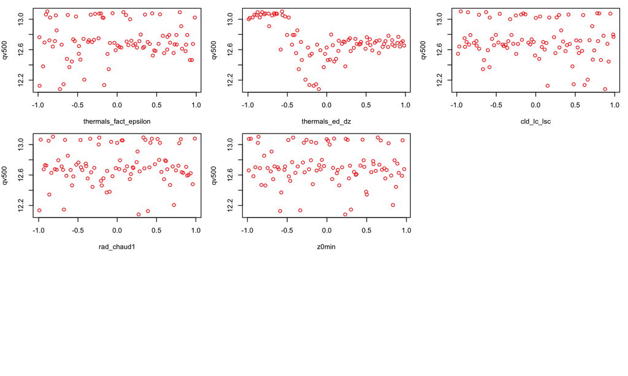

```r
metric = c('qv500')
nmetric = length(metric)
cands = names(tData)[-which(names(tData) == metric)]
param = cands[-which(cands == "Noise")]
nparam = length(param)

if(nparam*nmetric<2){ par(mfrow = c(1, 1), mar=c(4, 4, 1, 1))
} else if(nparam*nmetric <= 4){ par(mfrow = c(2, 2), mar=c(4, 4, 1, 1))
} else if(nparam*nmetric <= 9){ par(mfrow = c(3, 3), mar=c(4, 4, 1, 1))
} else if(nparam*nmetric <= 16){ par(mfrow = c(4, 4), mar=c(4, 4, 1, 1))
} else if(nparam*nmetric <= 25){ par(mfrow = c(5,5), mar=c(4, 4, 1, 1)) }
for ( iparam in 1:nparam ) {
  for (j in 1:nmetric) {
    plot(tData[,iparam],tData[,nparam+j+1],col=2,xlab=cands[iparam],ylab=metric[j],
         ylim=range(tData[,nparam+j+1]))
  }
}
```

```r
myem.lm.cnrm = EMULATE.lm(Response="qv500", tData=tData, tcands=cands, tcanfacs=NULL,TryFouriers=TRUE,maxOrder=4,
                          maxdf = ceiling(length(tData[,1])/10)+1)
myem.gp.cnrm = EMULATE.gpstan(meanResponse=myem.lm.cnrm, tData=tData,
                                additionalVariables=param, FastVersion = TRUE)
```

We proceed to producing a diagnostics plot (Leave-One-Out):

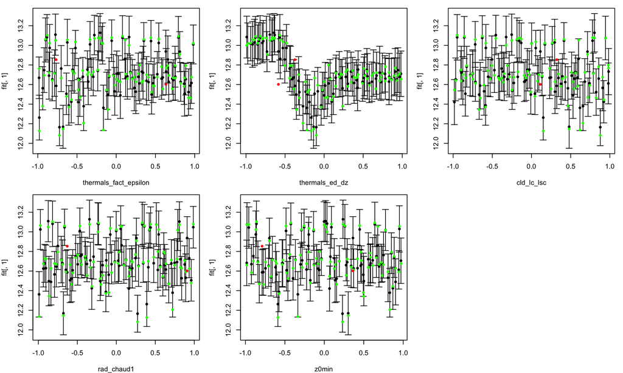

```r
tLOOs1 <- LOO.plot(StanEmulator = myem.gp.cnrm, ParamNames=cands)
```

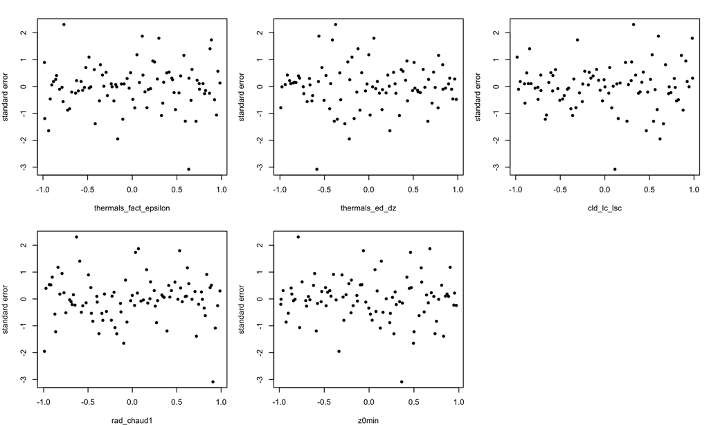

```r
std.err <- CalStError(tLOOs1, tData$qv500)
par(mfrow = c(2, 3), mar = c(4, 4, 2, 1))
for(i in 1:nparam) {
  plot(tData[, param[i]], std.err, pch = 20, xlab = param[i],
       ylab = 'standard error')
}
```

## Fitting a mixture model to standard errors

```r
tData.mixture = as.data.frame(cbind(tData[, param], std.err))
myem.mixture <- MIXTURE.design(formula =std.err~thermals_ed_dz, tData.mixture = tData.mixture, L = 3)
```

Let’s produce results of fitting a mixture model with $L=3$.

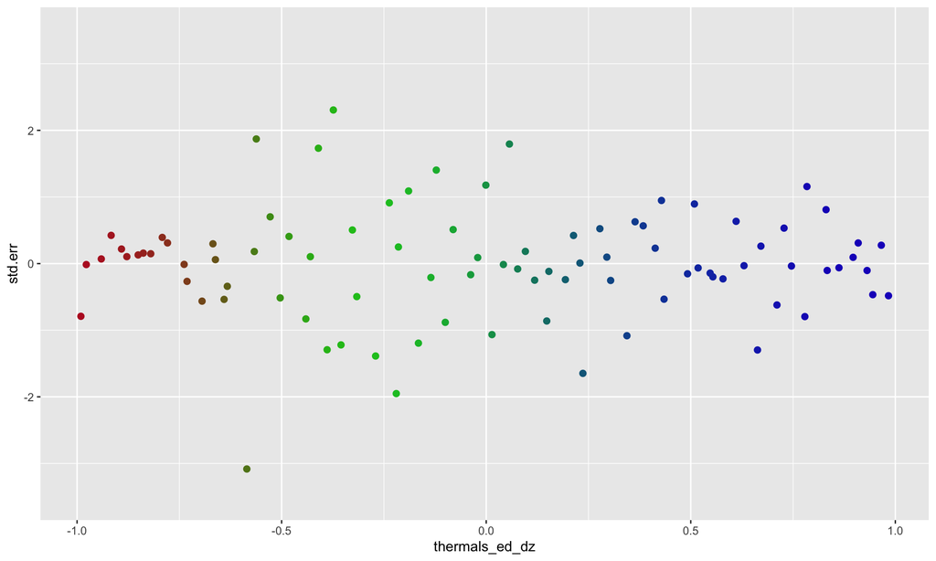

```r
mixture.cnrm <- data.frame(cbind(tData[, param], std.err,
myem.mixture$MixtureMat))
names(mixture.cnrm) <- c(param, 'std.err', 'red', 'blue', 'green')
p1 <- ggplot(mixture.cnrm, aes(x = thermals_ed_dz, y = std.err, col = rgb(red = red, blue = blue, green = green), ymin = -3.5, ymax=3.5)) +
  geom_point(size = 2) + scale_color_identity()
p1
```

## Fitting a nonstationary GP model

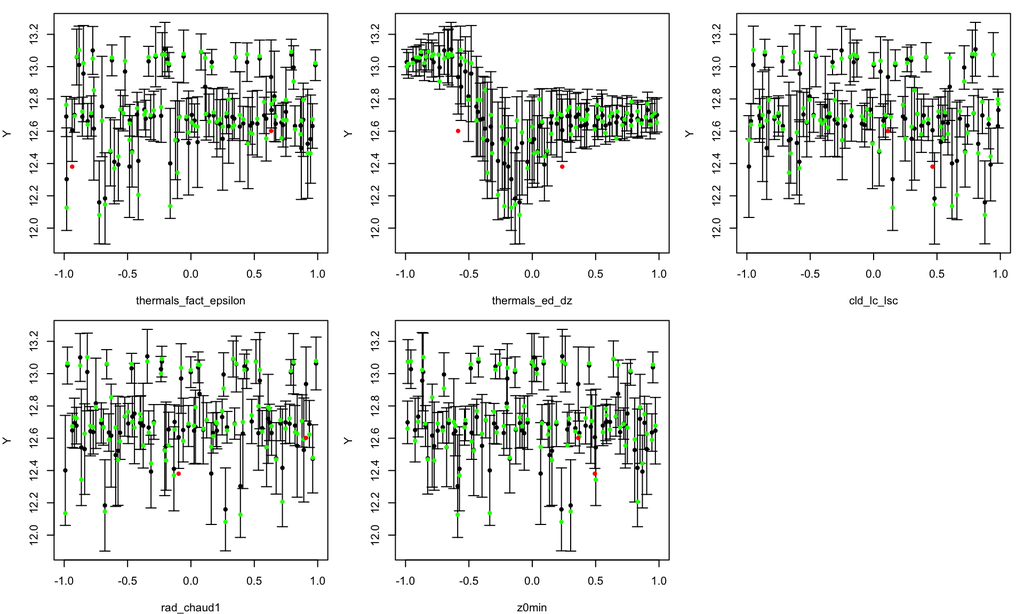

```r
myem.gp.cnrm.nst <- EMULATE.gpstanNSt(meanResponse=myem.lm.cnrm, tData=tData,
                                        additionalVariables=param,
                                        FastVersion = TRUE, mixtureComp = myem.mixture)
clim.nst.LOO <- LOO.plot.NSt(StanEmulator = myem.gp.cnrm.nst, ParamNames=param)
```